# MATH 3382: Homework 10 - Due Dec. 1 at 2PM

Ivy Truong

2022-12-01

# Instructions:

**Submit your work electronically as an R Markdown file extension `.Rmd`.**

Upload your file into the Homework 10 assignment in Canvas before **2 PM on Thursday, Dec 1**.

**You must provide supporting work for your all of your answers.**

- That work might be inserting some R code cells.
  - **Feel free to insert as much R code as you like.**
  - You must interpret or explain how the output of a code cell is being utilized to solve the problem.
  - **Code with incomplete or missing explanations of why the output is useful may not receive full credit.**
- It might involve doing some algebra and/or calculus (integrating, differentiating, etc).
  - **Be sure to type/write out the steps of your work so I can see how you arrived at your answer.**
  - **If typing takes too long no problem.** You can write out the support work on paper and hand that in before class.
- Probably it a little bit of both on most problems, but you decide how you want to solve the problems!

## Important Academic Policies:

- **Be your own work.** Though you may collaborate with others, everyone is responsible for writing up the work in their own way using their own methods. Plagiarism of any form is not tolerated.
- **Be complete.** You must provide all work and/or explanations needed to find the solution. Answers with insufficient or incomplete supporting work may lose credit.
- **Adhere to the Code of Academic Honesty.**
- **Be clearly written (and legible if written).** Your solution to a problem must be clear, written in complete sentences. You may lose credit for work that is unclear or hard to follow.

### Let me know if you need help, and **GOOD LUCK!!!**

# Question 1

Suppose you do an experiment as follows. Five volunteers wish to quit smoking cigarettes. They are randomly split into two groups.

- Three people are placed into a reward only group.
  - If after six months they have successfully quit, they receive a $\$100$ reward.
  - If they are not successful, no penalty.
- The other two people make a $\$50$ deposit.
  - If after six months they have successfully quit, they receive a reward of $\$150$.
  - If they have not quit smoking after six months, they lose their $\$50$ deposit.

The results of the experiment are given below. The names are modified so that names that begin with $S$ denote they successfully quit, while those that begin with $N$ denote they were not successful quitting.

| Group | Result |
| --- | --- |
| Reward Only | Sam , Sole, Nino |
| Deposit | Serge, Nell |

Researchers want to test to see if the proportion of people that quit is higher when they are rewarded as opposed to when they are penalized by losing a deposit. Answer the questions below to complete the steps of a hypothesis test to answer this question.

## Question 1a

Set up the hypotheses for this test.

### Solution to Question 1a

**Be sure to express each hypothesis both in words and using appropriate notation.**

$H_0$: There is no difference in the proportion of people that quit smoking when they are put in the reward only group or deposit group.

$p_{reward} - p_{deposit} = 0$

$H_a$: The proportion of of people that quit smoking is higher when they are put in the reward only group than the deposit group.

$p_{reward} - p_{deposit} > 0$

p = probability that people quit smoking

## Question 1b

Compute the observed test statistic.

- *Hint: Find the difference in the proportion of people in each sample that successfully quit smoking after six months.*

### Solution to Question 1b

Be sure to provide supporting work.

```r
reward_success <- 2/3
deposit_success <- 1/2

#test statistic is proprotion reward group was successful - proportion deposit group was successful
(obs_test_stat <- reward_success - deposit_success)
```

```
## [1] 0.1666667
```

The observed test statistic is 0.16667.

## Question 1c

How many total permutation resamples are possible? In other words, out of a total of 5 people, how many ways can we select three people to be in the reward only group?

### Solution to Question 1c

Be sure to provide supporting work.

```r
# Feel free to use code to help show your work
choose(5, 3)
```

```
## [1] 10
```

There are 10 ways to choose 3 people from a group of 5.

## Question 1d

Type out all possible permutations resamples and calculate the difference in sample proportions for each resample.

### Solution to Question 1d

The first couple of rows in the table below have been completed. Add additional rows and complete the table. You should have as many samples in your table as you identified in Question 1c.

For example complete the list below:

| Sample | Reward Only Group | Deposit Group | Test stat |
| --- | --- | --- | --- |
| 1 | Sam, Sole, Nino | Serge, Nell | $1/6$ |
| 2 | Serge, Sole, Nino | Sam, Nell | $1/6$ |
| 3 | Nell, Sole, Nino | Serge , Sam | $-2/3$ |
| 4 | Sam, Serge, Nino | Nell, Sole | $1/6$ |
| 5 | Sam, Serge, Nell | Nino, Sole | $1/6$ |
| 6 | Sam, Sole, Nell | Nino, Serge | $1/6$ |
| 7 | Serge, Sole, Nell | Nino, Sam | $1/6$ |
| 8 | Nell, Nino, Serge | Sam, Sole | $-2/3$ |
| 9 | Nell, Nino, Sam | Serge, Sole | $-2/3$ |
| 10 | Sam, Sole, Serge | Nell, Nino | $1$ |

## Question 1e

Based on your previous answers, what is the P-value of the observed test statistic?

### Solution to Question 1e

Show or explain how you computed the P-value.

P value = P(test stat | H0 is true)

```r
#test statistic from the observed/original sample was 2/3 - 1/2 = 1/6
#the total number of possible permutations is 10

#out of all 10 samples, which ones have a test stat that matches the observed test stat (get the ratio)

#number of samples with test stat >= 1/6 / total number of samples
(p_val <- 7 / 10)
```

```
## [1] 0.7
```

The p value of the observed test statistic is 0.7.

# Question 2

A sample of 10 registered voters are randomly selected. Each voter was asked if they supported a bill forgiving student loans. They were also asked how much outstanding student loan debt they currently have (in thousands of US dollars). The results are summarized in the table below.

| ID | Support student loan forgiveness? | Outstanding Student Debt (thousands of dollars) |
| --- | --- | --- |
| 1 | YES | 8 |
| 2 | YES | 65 |
| 3 | YES | 0 |
| 4 | YES | 152 |
| 5 | YES | 12 |
| 6 | YES | 45 |
| 7 | NO | 115 |
| 8 | NO | 0 |
| 9 | NO | 0 |
| 10 | NO | 62 |

A researcher wants to perform a hypothesis test to determine whether voters that support the bill (responded `YES`) have more student debt, on average, compared to voters that do not support the bill (responded `NO`)? She can use the code below to perform part of the permutation test.

- DO NOT RUN THE CODE BELOW (unless you really want to).
- The questions that follow will ask you to explain what some parts of the code are doing.

```r
debt <- c(8, 65, 0, 152, 12, 45, 115, 0, 0, 62)
N <- 10^3 - 1 # Number of resamples we will create
result <- numeric(N)

for (i in 1:N)
{
  index <- sample(10, size = 6, replace = FALSE)
  result[i] <- mean(debt[index]) - mean(debt[-index])
}
```

## Question 2a

Explain what the first line in the for loop is doing.

- `index <- sample(10, size = 6, replace = FALSE)`

### Solution to Question 2a

Be sure to explain why each of inputs `10`, `size = 6` and `replace = FALSE` are used in the `sample()`.

This line of code is sampling 6 different values from 1 through 10 without replacement and saving those values in a variable named index. The first argument in the sample function is 10 because there were 10 people total surveyed in the observed sample. The second argument size is equal to 6 because we want to choose randomly 6 people to represent the people who said yes in this resample, similar to the number of people who said yes in the original observed sample. Replacement is equal to FALSE because we want different people each time instead of simulating that we are interviewing the same people (if that makes sense).

## Question 2b

Give a possible vector that could be the output stored to `index` as a result of `sample(10, size = 6, replace = FALSE)`

- For example, output could be a vector such as (1, 2, 3, 4, 5, 6).
- Give another such possible vector for `index` in the space below. Answers should vary.
- Do not use any code to help answer this question.

### Solution to Question 2b

- The vector `index` could be (8, 5, 3, 7, 2, 9).
- **Explain how you determined your answer in the space below.**

The vector index has values between 1 through 10, the vector size should be of size 6, and there should be no repeats in the vector index because we want to get 6 unique indexes/people. The values are randomized because sample chooses values in random order.

## Question 2c

Using your previous answer in Question 2b, what would be stored in the vector `debt[index]`.

- Refer to your vector `index` from Question 2b and the vector `debt` created earlier.
- **Do not use any code to help answer this question.**
- **Support your answer with a one sentence explanation of how you determined your answer.**

### Solution to Question 2c

- Based on my Solution to Question 2b, the vector `debt[index]` would be (0, 12, 0, 115, 65, 0).
- **Explain how you determined your answer in the space below.**

We can access the values in the debt vector using indexing notation. For example, debt[8] = 0. So debt[8,5,3,7,2,9] = (0,12,0,115,65,0).

## Question 2d

Using your previous answer in Question 2b, what would be stored in the vector `debt[-index]`.

- Refer to your vector `index` from Question 2b and the vector `debt` created earlier.
- **Do not use any code to help answer this question.**
- **Support your answer with a one sentence explanation of how you determined your answer.**

### Solution to Question 2d

- Based on my Solution to Question 2b, the vector `debt[-index]` would be (8, 152, 45, 62).
- **Explain how you determined your answer in the space below.**

The values that are not in index are (1, 4, 6, 10). So the values that the vector debt[-index] will output is the values that are stored in those positions 1, 4, 6, 10 in the debt vector.

# Question 3

```r
library(resampledata)
head(IceCream)
```

```
##            Brand VanillaCalories VanillaFat VanillaSugar ChocolateCalories
## 1 Baskin Robbins             260       16.0         26.0               260
## 2  Ben & Jerry's             240       16.0         19.0               260
## 3     Blue Bunny             140        7.0         12.0               130
## 4        Breyers             140        7.0         13.0               140
## 5      Brigham's             190       12.0         17.0               200
## 6          Bulla             234       13.5         21.8               266
##   ChocolateFat ChocolateSugar
## 1           14           31.0
## 2           16           22.0
## 3            7           14.0
## 4            8           16.0
## 5           12           18.0
## 6           15           22.6
```

## Question 3a

Explain why this is an example of a matched pairs data.

### Solution to Question 3a

This is an example of a matched pairs data because you want to compare a metric between two dependent samples. This example is comparing a metric between two samples that are in a matching category, which is ice cream, and the example wants to measure the difference in the two types/flavors of ice cream.

## Question 3b

Compute the mean number of calories for each of the two flavors separately.

### Solution to Question 3b

Answer the question using the code cell below.

```r
# Use code cell to answer
(mean_vanilla_calories <- mean(IceCream$VanillaCalories))
```

```
## [1] 191.4103
```

```r
(mean_chocolate_calories <- mean(IceCream$ChocolateCalories))
```

```
## [1] 198.7436
```

The mean calories for vanilla ice cream is 191.41, while the mean calories for chocolate ice cream is 198.74.

## Question 3c

State the hypothesis, **both practically speaking in words and using appropriate notation**.

### Solution to Question 3c

$H_0$: There is no difference in the mean difference between matched pairs of vanilla and chocolate ice cream calories.

$\mu_{C_{calories} - V_{calories}} = 0$

$H_a$: The mean difference between matched pairs shows that chocolate ice cream has more calories than vanilla ice cream.

$\mu_{C_{calories} - V_{calories}} > 0$

## Question 3d

Calculate the value of the relevant test statistic.

### Solution to Question 3d

Answer the question using the code cell below.

```r
# Use code cell to answer
diff_pairs <- IceCream$ChocolateCalories - IceCream$VanillaCalories
(obs_diff_pairs <- mean(diff_pairs))
```

```
## [1] 7.333333
```

The observed test statistic value is 7.33.

## Question 3e

Construct a permutation distribution to see the distribution of test statistics. Be sure your code includes the following:

- Include at least $N=10^5-1$ permutation resamples in your distribution.
- Your code should include a `for` loop to construct the permutation distribution.
- Display your permutation distribution as a histogram, and mark the observed test statistic with a vertical line on the histogram.

### Solution to Question 3e

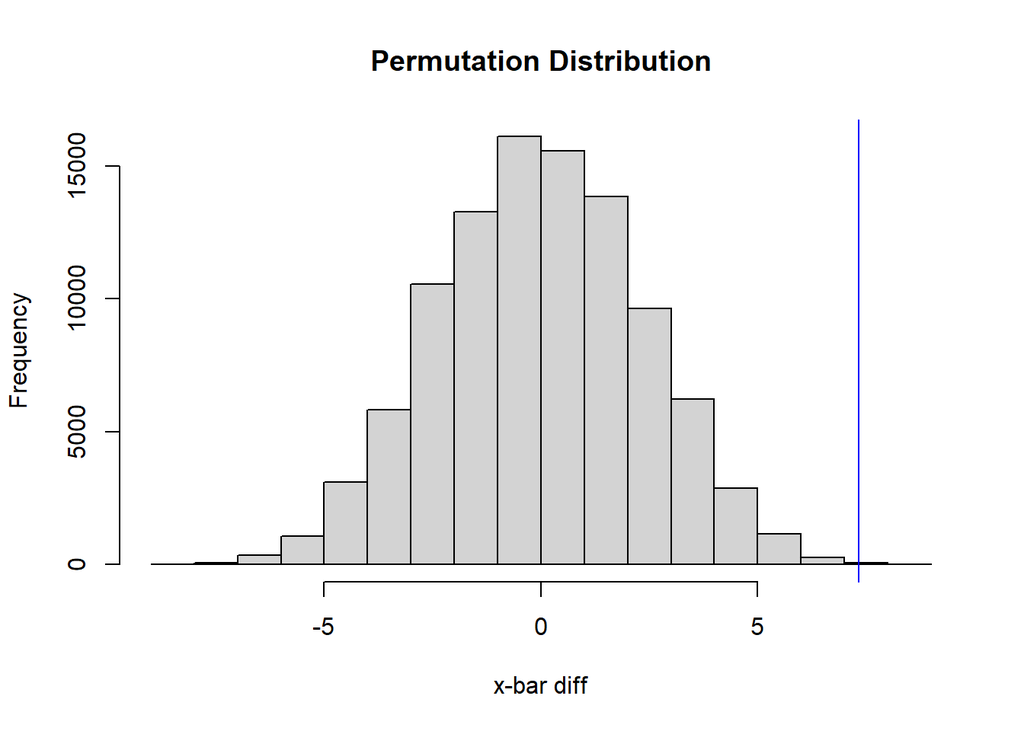

```r
# Create and plot a permutation distribution here
N <- 10^5 - 1
res <- numeric(N)

samp_length <- length(diff_pairs)

for(i in 1:N){
  sign <- sample(c(-1,1),size=samp_length,replace=TRUE)
  new_diff <- sign * diff_pairs
  res[i] <- mean(new_diff)
}

hist(res, xlab="x-bar diff", main="Permutation Distribution")
abline(v=obs_diff_pairs, col="blue")
```

## Question 3f

Calculate the P-value of the observed test statistic.

### Solution to Question 3f

```r
# Calculate P-value here

#probability that permutation distribution is greater than or equal to observed test statistic
#add 1 to include the observed/original sample
p_val_ice <- (sum(res >= obs_diff_pairs)+1)/(N+1)
p_val_ice
```

```
## [1] 0.00026
```

## Solution 3g

Make a decision using a 5% significance level. **Be sure to state your answer in the context of the problem** (i.e. do not just say *reject null* or *fail to reject null*).

### Solution to Question 3g

**Be sure to state your answer in the context of the problem** (i.e. do not just say *reject null* or *fail to reject null*).

5% = 0.05

# Question 4

The mean cholesterol level for vegetarians in the United States is 161 mg/dl, and the distribution is normal. You suspect vegetarians in your town have different cholesterol than the rest of the US. You gather data from a random sample of 24 vegetarians in your town, and you find a sample mean cholesterol level of 164 mg/dl with a sample standard deviation of 5 mg/dl. **Do these data support the claim that cholesterol levels of vegetarians in your town are different from the rest of the US?**

## Question 4a

State the hypotheses **using both appropriate notation and in practical language related to this context**.

### Solution to Question 4a

$H_0$: There is no difference in mean cholesterol levels between vegetarians from the local town and in the US.

$\mu_{veggie \ US} - \mu_{veggie \ town} = 0$

$H_a$: There is a difference in mean cholesterol levels between vegetarians from the local town and in the US.

$\mu_{veggie \ US} - \mu_{veggie \ town} \ne 0$

## Question 4b

Calculate the value of the test statistic of the observed sample.

### Solution to Question 4b

Use the code cell below to compute the observed test statistic.

```r
# compute the test statistic

US_mean <- 161 #US mean cholesterol for vegetarians
town_mean <- 164 #town mean cholesterol for vegetarians

t <- (town_mean - US_mean)/(5/sqrt(24)) #test statistic
t
```

```
## [1] 2.939388
```

## Question 4c

Based on your test statistic in Question 4b, compute the P-value. Since we do not have the raw data, you will need to apply formulas from classical methods of hypothesis testing (using CLT).

### Solution to Question 4c

```r
# Compute the P-value
# find probability that value is greater than or equal to test stat and less than or equal to test stat
# problem states that it is a normal distribution so pnorm will be used

p_val <- 2 * pt(t,24-1) #p value for two tailed test

p_val
```

```
## [1] 1.992636
```

normal distribution of all samples using CLT:

$\bar{X} \sim N(\mu, \frac{\sigma}{\sqrt{n}}) \\ \bar{X} \sim N(161, \frac{5}{\sqrt{24}})$  
$\frac{\bar{x} - \mu_0}{\frac{s}{\sqrt{n}}}$

## Question 4d

Make a decision using a **1% significance level**. Be sure to state your answer in the context of the problem. Do not just say *reject null* or *fail to reject null*.

### Solution to Question 4d

# Transactions Dataset For Question 5

## Initial Loading of Data

In the code cell below, we import a dataset to a dataframe named `transactions`.

```r
# import data as data frame
transactions <- read.csv(file = "https://raw.githubusercontent.com/CU-Denver-MathStats-OER/Statistical-Theory/main/Data/Transactions.csv",
                  header = TRUE,
                  sep = ",",)
summary(transactions)
```

```
##  transaction_id    product_id      customer_id     transaction_date
##  Min.   :    1   Min.   :  0.00   Min.   :   1.0   Length:20000
##  1st Qu.: 5001   1st Qu.: 18.00   1st Qu.: 857.8   Class :character
##  Median :10000   Median : 44.00   Median :1736.0   Mode  :character
##  Mean   :10000   Mean   : 45.36   Mean   :1738.2
##  3rd Qu.:15000   3rd Qu.: 72.00   3rd Qu.:2613.0
##  Max.   :20000   Max.   :100.00   Max.   :5034.0
##
##  online_order    order_status          brand           product_line
##  Mode :logical   Length:20000       Length:20000       Length:20000
##  FALSE:9811      Class :character   Class :character   Class :character
##  TRUE :9829      Mode  :character   Mode  :character   Mode  :character
##  NA's :360
##
##
##
##  product_class      product_size         list_price      standard_cost
##  Length:20000       Length:20000       Min.   :  12.01   Min.   :   7.21
##  Class :character   Class :character   1st Qu.: 575.27   1st Qu.: 215.14
##  Mode  :character   Mode  :character   Median :1163.89   Median : 507.58
##                                        Mean   :1107.83   Mean   : 556.05
##                                        3rd Qu.:1635.30   3rd Qu.: 795.10
##                                        Max.   :2091.47   Max.   :1759.85
##                                                          NA's   :197
##  product_first_sold_date
##  Min.   :33259
##  1st Qu.:35667
##  Median :38216
##  Mean   :38200
##  3rd Qu.:40672
##  Max.   :42710
##  NA's   :197
```

## Cleaning the Data

- From the summary above, we can see there are some issues with the date. To name a few:
  - There are some missing values that are coded as `NA`.
  - Categorical variables are saved as character strings, and not as `factors`.
  - Dates in `transaction_data` are saved as character strings.
  - Dates in `product_first_sold_date` are saved as `numeric`.
- In the code cell below, we address some of these:
  - We remove all rows that have any missing values.
  - We convert a variables in columns 5 to 10 to `factors`.
  - We are not going to be working with dates, so we ignore that issue.

```r
# Removing observations with any missing data
transactions <- na.omit(transactions)

# Convert categorical variables to factors
for (i in 5:10)
{
  transactions[,i] <- factor(transactions[,i])
}

summary(transactions)
```

```
##  transaction_id    product_id     customer_id   transaction_date   online_order
##  Min.   :    1   Min.   :  0.0   Min.   :   1   Length:19445       FALSE:9706
##  1st Qu.: 4976   1st Qu.: 18.0   1st Qu.: 857   Class :character   TRUE :9739
##  Median : 9985   Median : 45.0   Median :1741   Mode  :character
##  Mean   : 9989   Mean   : 45.8   Mean   :1739
##  3rd Qu.:14997   3rd Qu.: 72.0   3rd Qu.:2615
##  Max.   :20000   Max.   :100.0   Max.   :5034
##     order_status              brand        product_line   product_class
##  Approved :19273   Giant Bicycles:3244   Mountain:  418   high  : 2952
##  Cancelled:  172   Norco Bicycles:2863   Road    : 3894   low   : 2906
##                    OHM Cycles    :2993   Standard:13920   medium:13587
##                    Solex         :4169   Touring : 1213
##                    Trek Bicycles :2931
##                    WeareA2B      :3245
##  product_size     list_price      standard_cost     product_first_sold_date
##  large : 3900   Min.   :  12.01   Min.   :   7.21   Min.   :33259
##  medium:12767   1st Qu.: 575.27   1st Qu.: 215.14   1st Qu.:35667
##  small : 2778   Median :1163.89   Median : 507.58   Median :38216
##                 Mean   :1107.34   Mean   : 555.59   Mean   :38202
##                 3rd Qu.:1635.30   3rd Qu.: 795.10   3rd Qu.:40672
##                 Max.   :2091.47   Max.   :1759.85   Max.   :42710
```

## Summarizing Transaction Variables

The dataframe `transaction` we created is random sample of sales transactions at a bicycle shop[^1]. Each observation corresponds to the sale of an individual item. There are a total of 13 variables in the dataset. We will not be interested in most. The variables of interest are defined below:

- `online_order`: TRUE means the sale was online. FALSE means the sale was in-store.
- `brand`: The brand of the item purchased. For example: Giant Bicycles, Solex, WeareA2B, Trek Bicycles, …
- `product_line`: Describes what type of bicycle the purchase is for. For example: Mountain, Road, Standard, and Touring.
- `list_price`: The amount the item was sold for.
- Feel free to play around with different plots to get an sense of the data.
- Some examples are below.

### Displaying Categorical Data: Brands

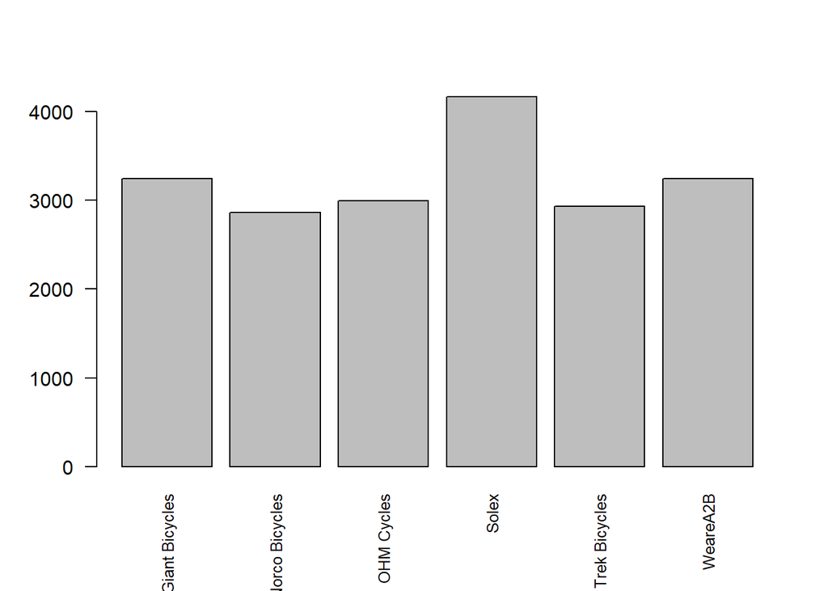

```r
# Bar plot of brands
plot(transactions$brand,
     las = 2,  # this option rotates labels
     cex.names = 0.8)  # this option shrinks fontsize
```

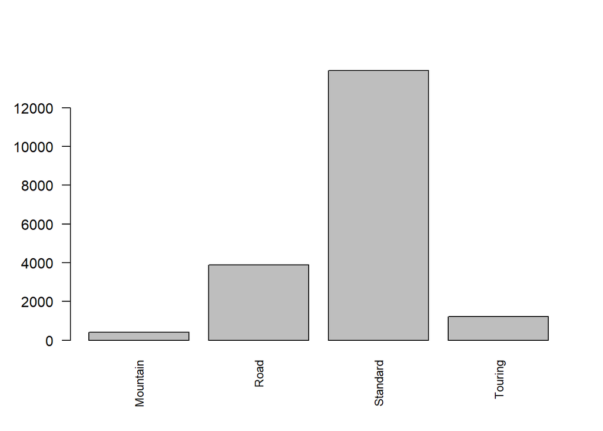

```r
plot(transactions$product_line,
     las = 2,  # this option rotates labels
     cex.names = 0.8)  # this option shrinks fontsize
```

### Displaying Numerical Data: List Price

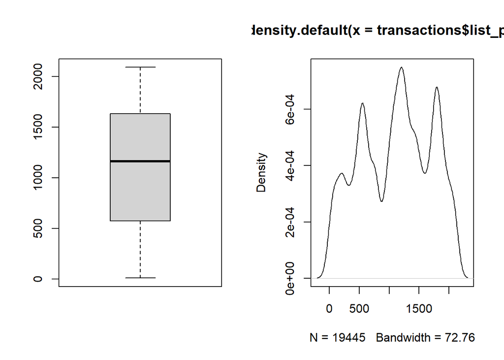

```r
par(mfrow=c(1,2))  # displays figures in 1 by 2 array

boxplot(transactions$list_price)  # boxplot
plot(density(transactions$list_price))  # density plot
```

```r
#hist(transactions$list_price, breaks=10)  # histogram

par(mfrow=c(1,1))  # resets display back to 1 figure.
```

## You Must Load and Create the `transactions` Dataframe Before Solving Question 5

# Question 5

For each statistical questions in Question 5a, Question 5b, and Question 5c, answer the following questions:

1. State the hypothesis, both practically speaking in words and using appropriate notation.
2. Calculate the value of the relevant test statistic. Complete the R code block to show how you computed this value.
3. Construct a permutation distribution to see the distribution of test statistics.
- Include at least $N=10^5-1$ permutation resamples in your distribution.
- Construct the permutation distribution using a `for` loop.
- Display your permutation distribution as a histogram, and mark the observed test statistic(s) with vertical line(s) on the histogram.
4. Calculate the P-value of the observed test statistic.
5. Make a decision using a 5% significance level. Be sure to state your answer in the context of the problem. Do not simply say “reject null: or”fail to reject null”.

## Question 5a

Are list prices of the brand `Giant Bicycles` different from the list prices of the brand `WeareA2B`? Perform a hypothesis comparing the mean list prices for each `brand`.

### Solution to Question 5a

1. State the hypothesis, both practically speaking in words and using appropriate notation.

$H_0$: There is no difference between the mean prices from Giant Bicycles and the mean prices from WeareA2B.

$\mu_{Giant \ Bicycles} - \mu_{WeareA2B} = 0$

$H_a$: There is a difference between the mean prices from Giant Bicycles and the mean prices from WeareA2B.

$\mu_{Giant \ Bicycles} - \mu_{WeareA2B} \ne 0$

2. Calculate the value of the relevant test statistic. Complete the R code block below to show how you computed this value.

```r
# Note the symbol | is the logical "OR" in R
pooled <- subset(transactions, select = "list_price",
                 brand == "Giant Bicycles" | brand == "WeareA2B",
                 drop = T)

giant <- subset(transactions, select = "list_price",
                brand == "Giant Bicycles", drop = T)

wearea2b <- subset(transactions, select = "list_price",
                brand == "WeareA2B", drop = T)

observed <- mean(giant) - mean(wearea2b)  # compute the observed test stat
observed  # print output of previous line
```

```
## [1] -29.03429
```

3. Construct a permutation distribution to see the distribution of test statistics.

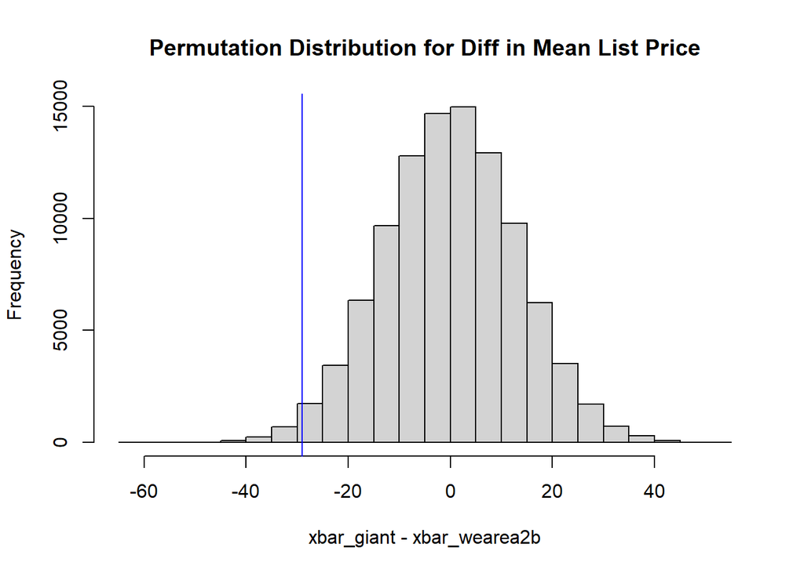

```r
total <- length(pooled)  # size of pooled sample
m <- length(giant)  # size of sample 1, giant bicycles

N <- 10^5 - 1  # Number of resamples we will create
result <- numeric(N)  # permutation sample differences stored here


for (i in 1:N)
{
  index <- sample(total, size = m, replace = FALSE)
  result[i] <- mean(pooled[index]) - mean(pooled[-index])
}

# Creates histogram to display permutation distribution.
hist(result, xlab = "xbar_giant - xbar_wearea2b",
     main = "Permutation Distribution for Diff in Mean List Price")
abline(v = observed, col = c("blue"))
```

4. Calculate the P-value of the observed test statistic.

```r
# Use code cell to compute P-value
# left_tail <- (sum(result <= observed)+1)/(N+1)
# right_tail <- (sum(result >= observed)+1)/(N+1)
#
# pval_brand <- left_tail + right_tail
# pval_brand
```

## Question 5b

Is the variance in list price of all `Road` bikes less than the variance in list price of all `Standard` bikes?

- Note `Road` and `Standard` are values of the variable `product_line`.

### Solution to Question 5b

1. State the hypothesis, both practically speaking in words and using appropriate notation.

$H_0$: There is no difference in the variance of the price of Road bikes and the variance of the price of Standard bikes.

$\sigma^2_{Road} - \sigma^2_{Standard} = 0$

$H_a$: The variance of the price of Road bikes are less than the variance of the price of Standard bikes.

$\sigma^2_{Road} - \sigma^2_{Standard} < 0$

2. Calculate the value of the relevant test statistic. Create your own code below.

```r
# Calculate observed test statistic
road <- subset(transactions, select = "list_price",
                product_line == "Road", drop = T)
standard <- subset(transactions, select = "list_price",
                product_line == "Standard", drop = T)
pooled_prod <- subset(transactions, select = "list_price",
                product_line == "Standard" | product_line == "Road", drop = T)

obs_var <- var(road) - var(standard)
obs_var
```

```
## [1] -38304.56
```

3. Construct a permutation distribution to see the distribution of test statistics. Be sure to include a plot of the distribution (as a histogram) and include vertical line(s) at the observed test statistic(s).

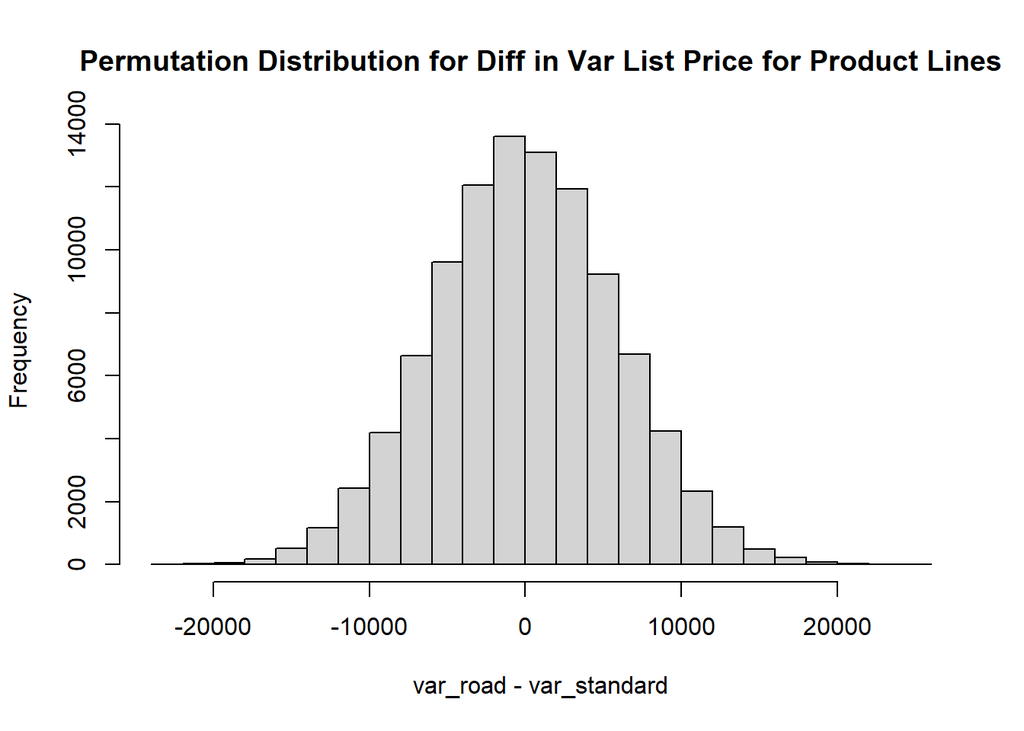

```r
# create and plot a permutation distribution
total_prod <- length(pooled_prod)
samp1 <- length(road)

N <- 10^5 - 1
result_var <- numeric(N)

for(i in 1:N){
  index1 <- sample(total_prod, size=samp1, replace = FALSE)
  result_var[i] <- var(pooled_prod[index1]) - var(pooled_prod[-index1])
}

hist(result_var, xlab = "var_road - var_standard",
     main = "Permutation Distribution for Diff in Var List Price for Product Lines")
abline(v = obs_var, col = c("blue"))
```

4. Calculate the P-value of the observed test statistic.

```r
# Use code cell to compute P-value
```

## Question 5c

Is the proportion of online bicycle sales that have a list price more than 1,000 dollars greater than the proportion of in-store bicycle sales that have a list price more than 1,000 dollars?

### Solution to Question 5c

1. State the hypothesis, both practically speaking in words and using appropriate notation.

$H_0$: There is no difference between the proportion of online bicycle sales that have a list price more than 1,000 dollars and the proportion of in store bicycle sales that have a list price more than 1,000 dollars.

$\hat{p}_{online} - \hat{p}_{inStore} = 0$

$H_a$: The proportion of online bicycle sales with a list price more than 1,000 dollars is greater than the proportion of online bicycle sales that have a list price more than 1,000 dollars.

$\hat{p}_{online} - \hat{p}_{inStore} > 0$

2. Calculate the value of the relevant test statistic. Create your own code below.

```r
# Calculate observed test statistic
online <- subset(transactions, select = "list_price",
                online_order == TRUE, drop = T)
inStore <- subset(transactions, select = "list_price",
                online_order == FALSE, drop = T)
pooled_orders <- subset(transactions, select = "list_price", drop = T)

# sum(online > 1000) + sum(inStore > 1000)
# length(pooled_orders)

total_online <- length(online)
total_inStore <- length(inStore)

prop_online <- sum(online > 1000) / total_online
prop_inStore <- sum(inStore > 1000) / total_inStore

# prop_online
# prop_inStore

obs_prop <- prop_online - prop_inStore
obs_prop
```

```
## [1] 0.0009459123
```

3. Construct a permutation distribution to see the distribution of test statistics. Be sure to include a plot of the distribution (as a histogram) and include vertical line(s) at the observed test statistic(s).

[figure not shown]

```r
# create and plot a permutation distribution
total_orders <- length(pooled_orders)
samp2 <- total_online

N <- 10^5 - 1
result_prop <- numeric(N)

for(i in 1:N){
  index2 <- sample(total_orders, size=samp2, replace = FALSE)
  sampprop_online <- sum(pooled_orders[index] > 1000) / samp2
  sampprop_inStore <- sum(pooled_orders[-index] > 1000) / (total_orders - samp2)
  result_prop[i] <- sampprop_online - sampprop_inStore
}

hist(result_var, xlab = "prop_online -  prop_inStore",
     main = "Permutation Distribution for Proportions of Online and Offline Orders")
abline(v = c(-obs_prop, obs_prop), col = c("blue","red"))
```

4. Calculate the P-value of the observed test statistic.

```r
# Use code cell to compute P-value
```